# Proving the selection weight ratio minimum

Jonathan Mellon

13/12/2021

In my [previous post](https://www.filedrawer.blog/post/minimum-post-strat-weight-is-response-rate/) I showed that the minimum inverse-probability weight in a simple random sample should be equal to the response rate of the survey. However, simple random samples are basically non-existent in the real world, so I need to work out the equivalent constraint for complex survey designs.

This post summarizes my progress so far towards doing that.

In that post I speculated that the constraint for $i$’s weight should be:

$$\frac{FinalWeight_i}{SelectionWeight_i} >= RR_{total}$$

# Does it work in practice?

After an hour of failing to work out an analytic proof, I thought it would be worth doing a simulation to see whether this claim is at least empirically true.

Rich people respond at 100% and poor people respond at 30%.

```r
options(scipen=9999)


simRR <- function(pop.n, poor.rr, rich.rr, sample.n, big.hh.rich = F) {
  hhs <- sample(1:pop.n, replace = T)
  hhs <- as.numeric(factor(hhs))
  hh.sizes <- table(hhs)[as.character(hhs)]

  if(big.hh.rich) {
    wealth <- ifelse(rbinom(size = 1 , prob = (1 - (1 / hh.sizes)), n=pop.n), "Rich", "Poor")
  } else {
    wealth <- ifelse(rbinom(size = 1 , prob = 0.5, n=pop.n), "Rich", "Poor")
  }


  sampled.hh <- sample(unique(hhs), sample.n, replace = F)
  sampled.people <- c()
  for(ii in sampled.hh){
    sampled.people <- c(sampled.people, sample(rep(which(hhs==ii), 2), 1))
  }

  wealth.sampled <- wealth[sampled.people]
  respondents <- sampled.people[
    (wealth.sampled=="Poor") & (rbinom(n=sample.n, prob = poor.rr, size = 1)==1) |
      (wealth.sampled=="Rich") & (rbinom(n=sample.n, prob = rich.rr, size = 1)==1)]

  prop.table(table(wealth[respondents]))
  respondent.hh.size <- table(hhs)[as.character(hhs[respondents])]
  probability.selection <- (sample.n / length(unique(hhs))) *
    (1/ respondent.hh.size)

  poor.rr.obs <- sum(wealth[respondents]=="Poor") / sum(wealth.sampled=="Poor")

  probability.response <- probability.selection *
    ifelse(wealth[respondents]=="Rich", rich.rr, poor.rr.obs)

  weights <- (1 / probability.response)
  selection.weights <- (1 / probability.selection)

  scaled.weights <- weights / mean(weights)
  scaled.selection.weights <- selection.weights / mean(selection.weights)
  ratios <- scaled.weights / scaled.selection.weights
  ratios2 <- weights / (selection.weights)
  ratios3 <- ratios / mean(ratios)
  actual.rr <- length(respondents) / sample.n

  out <- list(scaled.weights = scaled.weights,
              scaled.selection.weights = scaled.selection.weights,
              ratios = ratios, ratios2 = ratios2,
              ratios3 = ratios3,
              actual.rr = actual.rr)
  return(out)
}

output <- simRR(pop.n = 10000, poor.rr = 0.3, rich.rr = 1, sample.n = 1000, big.hh.rich = F)
```

So after simulating that I look at the response rate for the simulation 0.655 and the minimum value of the ratios of the final true weight to the selection weight 0.654. Not far off, but not identical to the response rate. So, it looks like my initial claim is on the right track but not exactly right.

Let’s try this a few more times and see whether it’s robust.

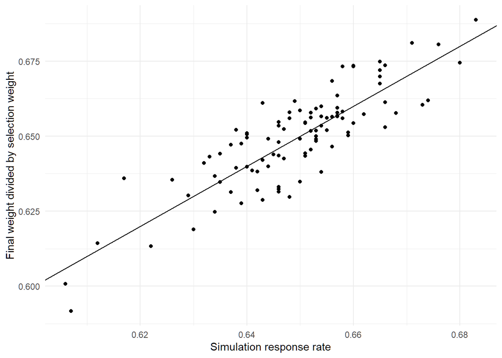

After 100 simulations, it’s clear there’s a very strong relationship, but this isn’t an exact match.

OK, so what’s going on with those ratios? The mean of the scaled inverse-probability weights is always exactly 1 in the simulation.

```r
set.seed(1298)
A <- abs(rnorm(1000))
B <- abs(rnorm(1000))
A <- A / mean(A)
B <- B / mean(B)
mean(A/B)
```

```
## [1] 4.292947
```

OK well what if I rescale the ratios so that they actually have a mean of 1 rather than just being close to that?

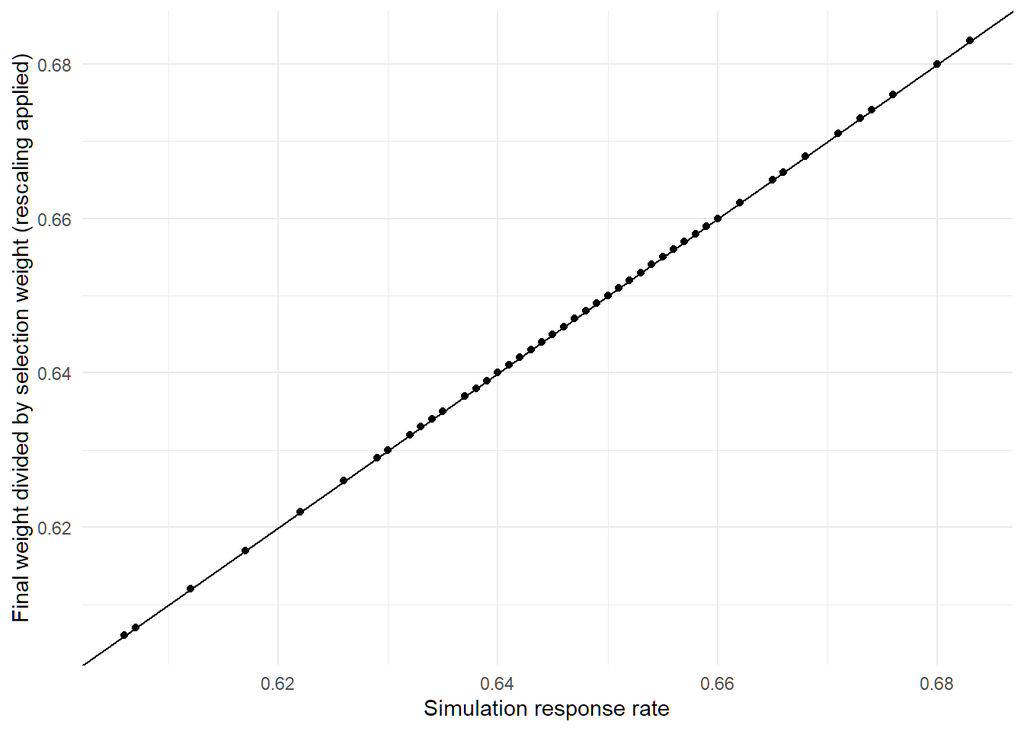

Apparently, that nails the minimum weight exactly. The mean absolute difference between this adjusted ratio and the response rate for the survey is just 0.0000000000000000677236045021345. At that point I’m willing to believe any remaining differences are just about floating point precision.

# Does this work with different simulation parameters?

OK well first of all, let’s make sure this actually holds up in a more complex simulation. I’ll set the poor response rate to 40% and say that people in bigger households are more likely to be rich (so that we have a correlation between selection probability and group response rates).

Apparently this fix still works and the adjusted ratios exactly match the response rate.

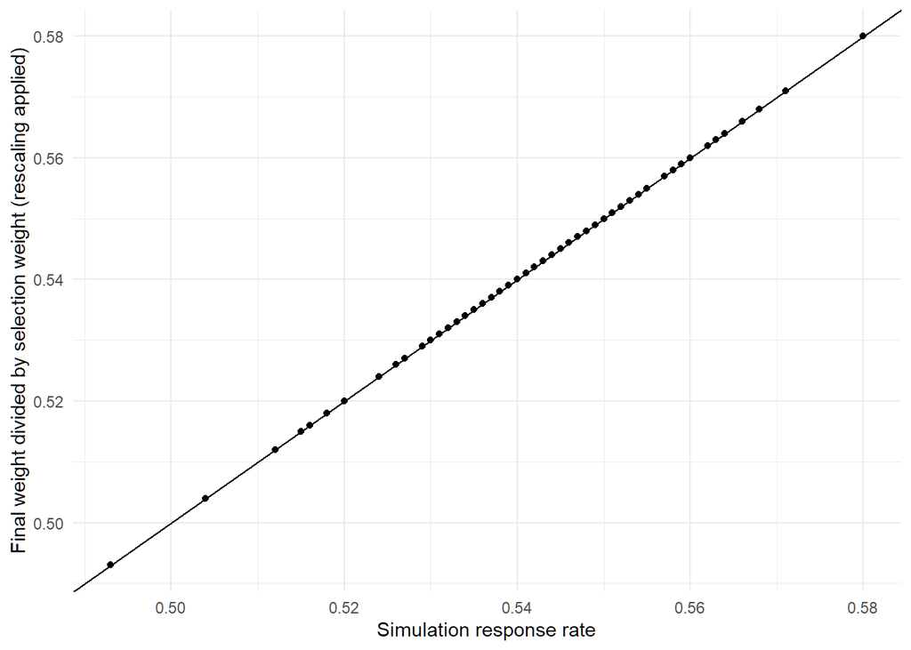

```r
ggplot(sims3, aes(x = rr, y = ratioadj)) + geom_point() + geom_abline()+
  xlab("Simulation response rate") +
  ylab("Final weight divided by selection weight (rescaling applied)") +
  theme_minimal()
```

# Summarizing the claim

So to formalize, it looks like the constraint works as follows. For each respondent, $j$, define:

$$r_j = \frac{FinalWeight_j}{SelectionWeight_j}$$

The adjusted ratio is defined as follows, where $\bar{r}$ is the mean ratio across all respondents to the survey:

$$r^{*}_j = \frac{r_j}{\bar{r}}$$
Based on my simulations, it appears that:

$$r^{*}_{j}>= RR_{total}$$

# But why does this work?

🤷